# Session Eight: Graphs - ggplot2 and plotly

Estimated Duration: 40 minutes

**<<** Back to Menu  
**>>** Session Nine

## ggplot2

### **ggplot2**

We shall plot some graphs using the World Population data. Because the data is currently in wide format, it needs to be converted to a long format for us to utilise the capabilities of ggplot2.

1. Install and load the reshape2 package.
2. Execute the code to re-order the data

`world_pop <- melt(World_Population)`

3. The melt function erroneously included the first column “Index” values so we need to remove the 235 rows by reassigning the variable

`world_pop <- world_pop[world_pop$Year!="Index",]`

4. Change the column names

`colnames(world_pop) <- c("Country","Region","Year","Population")`

5. View the data  
   `View(world_pop)’

**Plot Basic Graphs**

`ggplot(world_pop, aes(x=Region, y=Population))+`  
`geom_col()`

#### Histogram

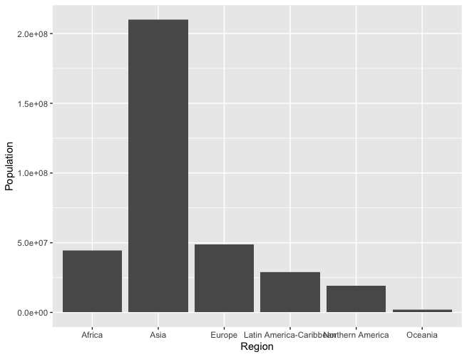

#### Pie Chart

Summarise the data by region  
`world_pop_region <- aggregate(world_pop_2020$Population, by=list(Region=world_pop_2020$Region), FUN=sum)`  
`colnames(world_pop_region) <- c("Region","Population")`

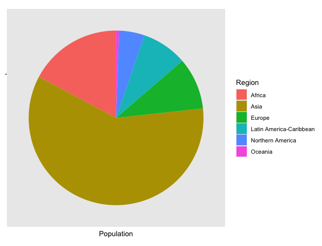

## plotly

### **plotly**

Install package plotly.

#### Histogram

Filter data by Country = Malaysia `world_pop_msia <- world_pop[world_pop$Country=="Malaysia",]`

Plot the graph  
`plot_ly(world_pop_msia,x=~Year, y=~Population, type="bar")`

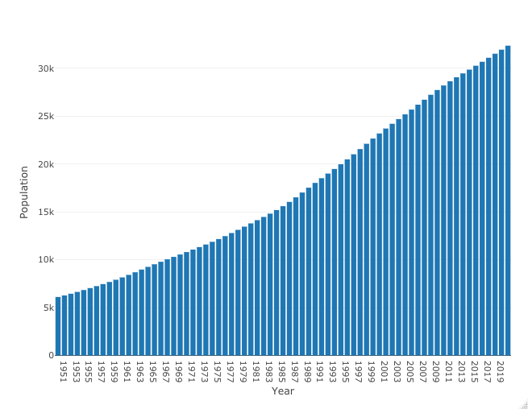

#### Pie Chart

Create a new data frame to filter the dataset to year 2020.

world_pop_2020 <- world_pop[world_pop$Year==2020,]

Plot the graph `fig <- plot_ly(world_pop_2020, labels = ~Region, values = ~Population, type = 'pie')`  
`fig <- fig %>% layout(title = '2020 World Population by Region',`  
`xaxis = list(showgrid = FALSE, zeroline = FALSE, showticklabels = FALSE),`  
`yaxis = list(showgrid = FALSE, zeroline = FALSE, showticklabels = FALSE))`  
`fig`

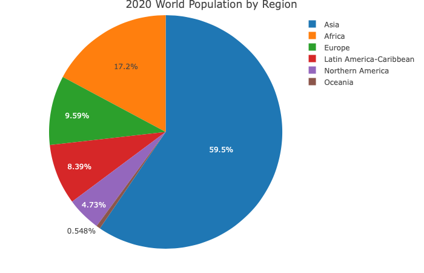

#### Scatter Plot

Create a new Data Frame  
`china_india_pop <- world_pop[world_pop$Country=="China" | world_pop$Country=="India",]`

Plot Graph  
`plot_ly(data = china_india_pop, x = ~Year, y = ~Population, color = ~Country, type='scatter')`

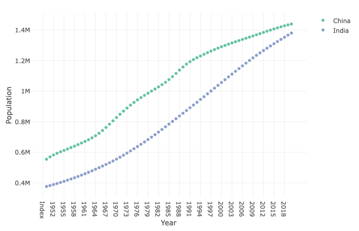